# Data visualization in practice

### 10.7.4 Accessing computed variables

So, we must make corrections about the number of nations. In this case, we need to use special access operator `..`:

```
aes(x = dollars_per_day, y = ..count..)
```

And the real plop will be:

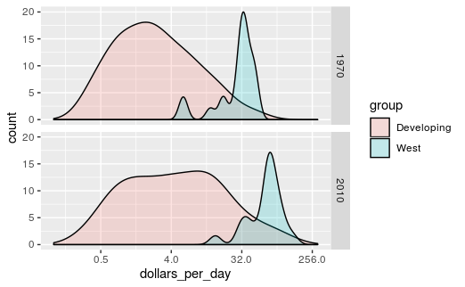

```r
p <- gapminder %>%
  filter(year %in% c(past_year, present_year) & country %in% country_list) %>%
  mutate(group = ifelse(group == "West", "West", "Developing")) %>%
  ggplot(aes(dollars_per_day, y = ..count.., fill = group)) +
  scale_x_continuous(trans = "log2", limit = c(0.125, 300))

p + geom_density(alpha = 0.2) +
  facet_grid(year ~ .)
```

And if we change smootheness:

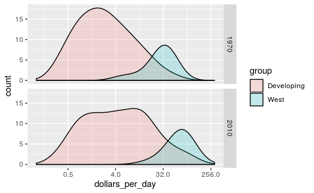

```r
p + geom_density(alpha = 0.2, bw = 0.75) + facet_grid(year ~ .)
```

Not only for two groups, all groups also can be plotted, in this time, by ridge plot:

```
Ignoring unknown parameters: adjust
```

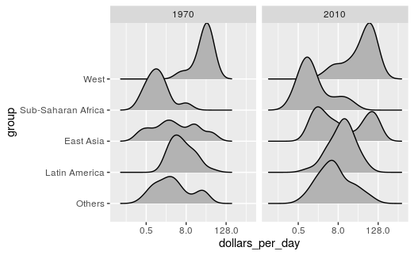

```r
gapminder %>%
  filter(year %in% c(past_year, present_year) & !is.na(dollars_per_day)) %>%
  ggplot(aes(dollars_per_day, group)) +
  scale_x_continuous(trans = "log2") +
  geom_density_ridges(adjust = 1.5) +
  facet_grid(. ~ year)
```

Or, we can use density plot just like we did above:

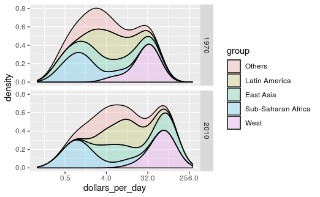

```r
gapminder %>%
    filter(year %in% c(past_year, present_year) & country %in% country_list) %>%
  group_by(year) %>%
  mutate(weight = population/sum(population)*2) %>%
  ungroup() %>%
  ggplot(aes(dollars_per_day, fill = group)) +
  scale_x_continuous(trans = "log2", limit = c(0.125, 300)) +
  geom_density(alpha = 0.2, bw = 0.75, position = "stack") + facet_grid(year ~ .)
```

### 10.7.5 Weighted densities

We can give each country to different ‘weigh’ by the importance of the data.

## 10.8 The ecological fallacy and importance of showing the data

In this section, we focus on describing the importance of variability within the groups when examining the relationship between a country’s infant mortality rates and average income.

We start by comparing these quantities across regions, but before doing this, we define a few more regions:

```r
gapminder <- gapminder %>%
  mutate(group = case_when(
    region %in% c("Western Europe", "Northern Europe","Southern Europe",
                    "Northern America", "Australia and New Zealand") ~ "West",
    region %in% "Northern Africa" ~ "Northern Africa",
    region %in% c("Eastern Asia", "South-Eastern Asia") ~ "East Asia",
    region == "Southern Asia"~ "Southern Asia",
    region %in% c("Central America", "South America", "Caribbean") ~ "Latin America",
    continent == "Africa" & region != "Northern Africa" ~ "Sub-Saharan Africa",
    region %in% c("Melanesia", "Micronesia", "Polynesia") ~ "Pacific Islands"))
```

We then compute these quantities for each region:

```r
surv_income <- gapminder %>%
  filter(year %in% present_year & !is.na(gdp) &
           !is.na(infant_mortality) & !is.na(group)) %>%
  group_by(group) %>%
  summarize(income = sum(gdp)/sum(population)/365,
            infant_survival_rate =
              1 - sum(infant_mortality/1000*population)/sum(population))

surv_income %>% arrange(income)
```

| group | income | infant_survival_rate |
| --- | --- | --- |
| Sub-Saharan Africa | 1.759299 | 0.9358607 |
| Southern Asia | 2.070296 | 0.9521295 |
| Pacific Islands | 2.704745 | 0.9560088 |
| Northern Africa | 4.942935 | 0.9703514 |
| Latin America | 13.244228 | 0.9831732 |
| East Asia | 13.439078 | 0.9848303 |
| West | 77.065524 | 0.9951445 |

And when we plot this, it will be almost linear:

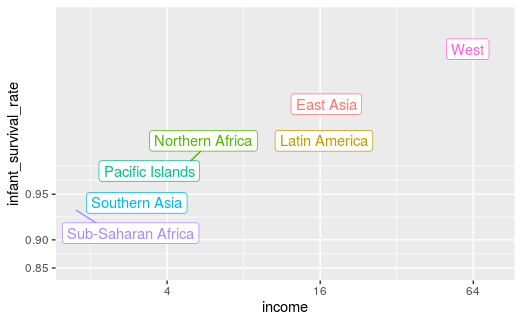

```r
library(ggrepel)

surv_income %>%
  ggplot(aes(income, infant_survival_rate, label = group)) +
  geom_label_repel(aes(color = group)) +
  scale_x_continuous(trans = "log2") +
  scale_y_continuous(trans = "logit", limit = c(0.850, 0.997)) +
  theme(legend.title = element_blank(), legend.position = "none")
```

### 10.8.2 Show the data

We’ll try to plot all countries.

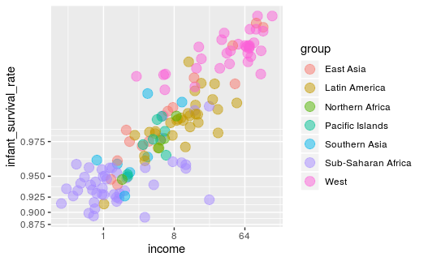

```r
surv_income <- gapminder %>%
  filter(year %in% present_year & !is.na(gdp) &
           !is.na(infant_mortality) & !is.na(group)) %>%
  group_by(group) %>%
  mutate(income = gdp/population/365,
            infant_survival_rate =
              1 - infant_mortality/1000*population/population)

surv_income %>%
  ggplot(aes(income, infant_survival_rate)) +
  geom_point(aes(color = group), alpha = 0.5, size = 4) +
  # geom_text_repel(aes(label = country[1], color = group), alpha = 0.5) +
  scale_x_continuous(trans = "log2") +
  scale_y_continuous(trans = "logit")
```